# Math 421 - Midterm

## II. Data Visualization

Continue with the data from part I.

1. Provides at least 10 meaningful plots. Comments on the plots. All plots should have title, caption, appropriate labels on x and y-axis

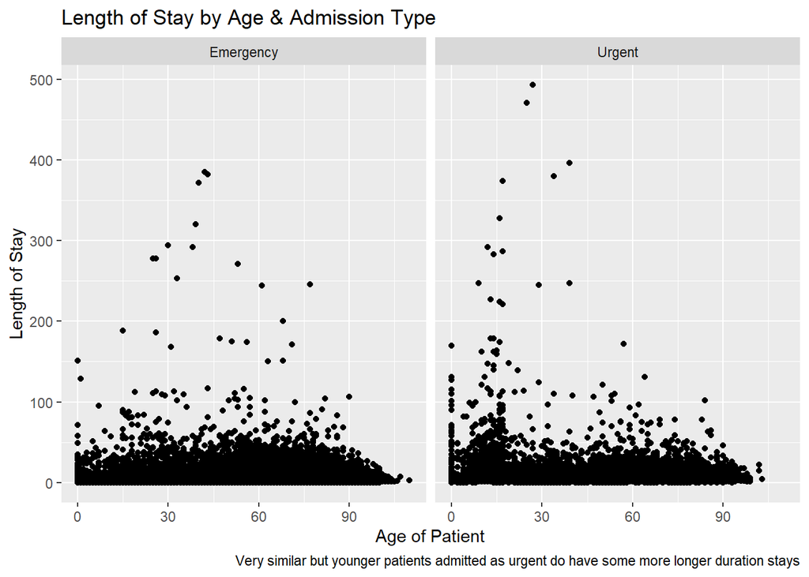

```r
library(knitr)
library(ggplot2)

df$admittype <- case_when(df$admtype %in% c(1) ~ 'Emergency',
  df$admtype %in% c(2)~ 'Urgent')

df %>% filter(admittype == 'Emergency' | admittype =='Urgent') %>% ggplot()+
  geom_point(mapping=aes(x=age, y=los))+
  facet_wrap(~admittype) +labs(x='Age of Patient',
       y = 'Length of Stay',
       title = 'Length of Stay by Age & Admission Type',
       caption = 'Very similar but younger patients admitted as urgent do have some more longer duration stays')
```

```r
gg1 <- df %>% filter(admittype == 'Emergency' | admittype =='Urgent') %>% ggplot()+
  geom_point(mapping=aes(x=age, y=los))+
  facet_wrap(~admittype) +labs(x='Age of Patient',
       y = 'Length of Stay',
       title = 'Length of Stay by Age & Admission Type',
       caption = 'Very similar but younger patients admitted as urgent do have some more longer duration stays')

ggsave(filename = 'midtermplot1.png', plot = gg1)
```

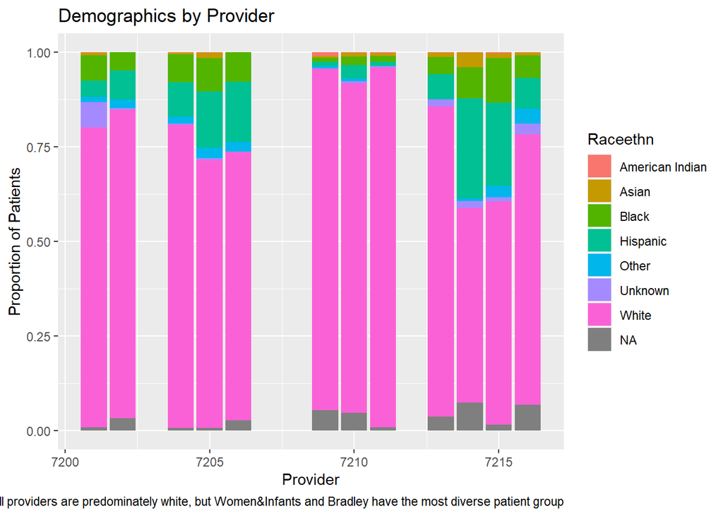

```r
df$Sex <- case_when(df$sex %in% c(1) ~ 'male',
  df$sex %in% c(2)~ 'female')

df$Raceethn <- case_when(df$raceethn %in% c(1) ~ 'White',
  df$raceethn %in% c(2)~ 'Black', df$raceethn %in% c(3) ~ 'Asian', df$raceethn %in% c(4) ~ 'American Indian',df$raceethn %in% c(5) ~ 'Native Hawaiian',df$raceethn %in% c(6) ~ 'Other',df$raceethn %in% c(7) ~ 'Hispanic',df$raceethn %in% c(9) ~ 'Unknown')


df %>%
ggplot(aes(x = provider,
                  fill=Raceethn))+
  geom_bar(position = 'fill') +labs(x='Provider',
       y = 'Proportion of Patients',
       title = 'Demographics by Provider',
       caption = 'Patients among all providers are predominately white, but Women&Infants and Bradley have the most diverse patient group')
```

```r
gg2 <- df %>%
ggplot(aes(x = provider,
                  fill=Raceethn))+
  geom_bar(position = 'fill') +labs(x='Provider',
       y = 'Proportion of Patients',
       title = 'Demographics by Provider',
       caption = 'Patients among all providers are predominately white, but Women&Infants and Bradley have the most diverse patient group')

ggsave(filename = 'midtermplot2.png', plot = gg2)
```

[figure not shown]

```r
df %>%
  filter(Sex=='male'|Sex=='female', b_wt > 0) %>%

  ggplot()+
  geom_point(mapping=aes(x=b_wt, y=nicu_day))+facet_wrap(~Sex)+labs(x='Birth Weight',
       y='Days in Nicu',
       title = 'Birth Weight VS Days in Nicu',
       caption = 'Lower birth weights seem to correspond with more days spent in the nicu')
```

```r
gg3 <- df %>%
  filter(Sex=='male'|Sex=='female', b_wt > 0) %>%

  ggplot()+
  geom_point(mapping=aes(x=b_wt, y=nicu_day))+facet_wrap(~Sex)+labs(x='Birth Weight',
       y='Days in Nicu',
       title = 'Birth Weight VS Days in Nicu',
       caption = 'Lower birth weights seem to correspond with more days spent in the nicu')

ggsave(filename = 'midtermplot3.png', plot = gg3)
```

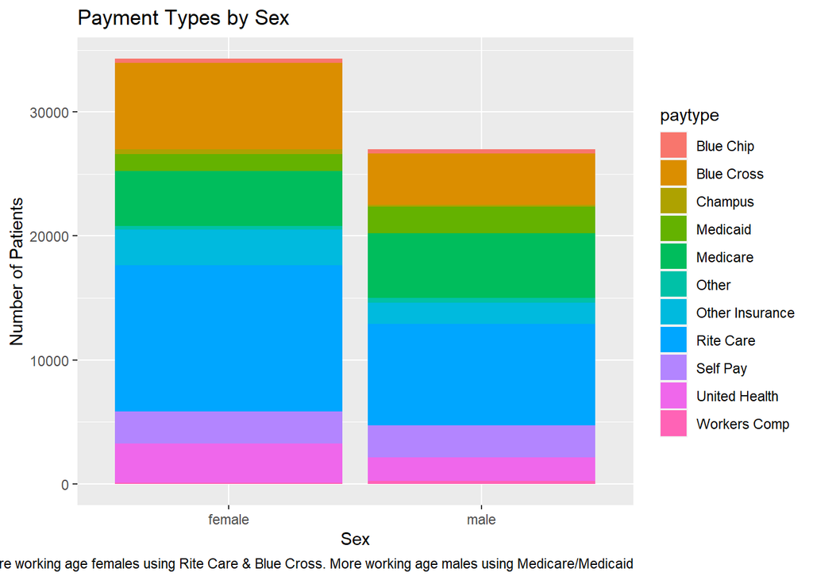

```r
df$paytype <- case_when(df$pay_ub92 %in% c(1,2) ~ 'Medicare',
  df$pay_ub92 %in% c(3,5)~ 'Medicaid', df$pay_ub92 %in% c(4) ~ 'Rite Care', df$pay_ub92 %in% c(6) ~ 'Blue Cross',df$pay_ub92 %in% c(7) ~ 'Blue Chip',df$pay_ub92 %in% c(9) ~ 'Other Insurance',df$pay_ub92 %in% c(8) ~ 'United Health',df$pay_ub92 %in% c(10) ~ 'Champus', df$pay_ub92 %in% c(11) ~ 'Workers Comp',df$pay_ub92 %in% c(12) ~ 'Other',df$pay_ub92 %in% c(13) ~ 'Self Pay')

df %>%
    filter(age>21, age<65, pay_ub92 <= 13, sex <=2) %>%
    ggplot()+
    geom_bar(mapping=aes(x=Sex, fill=paytype)) +labs(x='Sex',
       y='Number of Patients',
       title = 'Payment Types by Sex',
       caption = 'More working age females using Rite Care & Blue Cross. More working age males using Medicare/Medicaid')
```

```r
gg4 <- df %>%
    filter(age>21, age<65, pay_ub92 <= 13, sex <=2) %>%
    ggplot()+
    geom_bar(mapping=aes(x=Sex, fill=paytype)) +labs(x='Sex',
       y='Number of Patients',
       title = 'Payment Types by Sex',
       caption = 'More working age females using Rite Care & Blue Cross. More working age males using Medicare/Medicaid')

ggsave(filename = 'midtermplot4.png', plot = gg4)
```

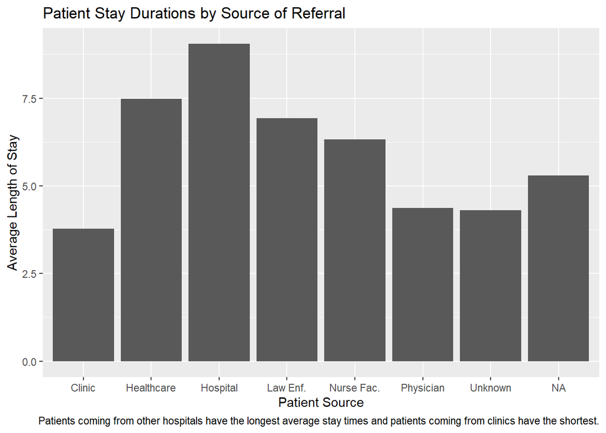

```r
df$Source <- case_when(df$asource %in% c(1) ~ 'Physician',
  df$asource %in% c(2)~ 'Clinic', df$asource %in% c(3) ~ 'HMO', df$asource %in% c(4) ~ 'Hospital',
  df$asource %in% c(5)~ 'Nurse Fac.', df$asource %in% c(6) ~ 'Healthcare',df$asource %in% c(7) ~ 'ER',
  df$asource %in% c(8)~ 'Law Enf.', df$asource %in% c(9) ~ 'Unknown')

df %>% group_by(Source) %>%
  summarise(avg_stay = mean(los)) %>%
  ggplot()+
  geom_col(mapping=aes(x=Source, y=avg_stay))+labs(x='Patient Source',
       y='Average Length of Stay',
       title = 'Patient Stay Durations by Source of Referral',
       caption = 'Patients coming from other hospitals have the longest average stay times and patients coming from clinics have the shortest.')
```

```r
gg5 <- df %>% group_by(Source) %>%
  summarise(avg_stay = mean(los)) %>%
  ggplot()+
  geom_col(mapping=aes(x=Source, y=avg_stay))+labs(x='Patient Source',
       y='Average Length of Stay',
       title = 'Patient Stay Durations by Source of Referral',
       caption = 'Patients coming from other hospitals have the longest average stay times and patients coming from clinics have the shortest.')

ggsave(filename = 'midtermplot5.png', plot = gg5)
```

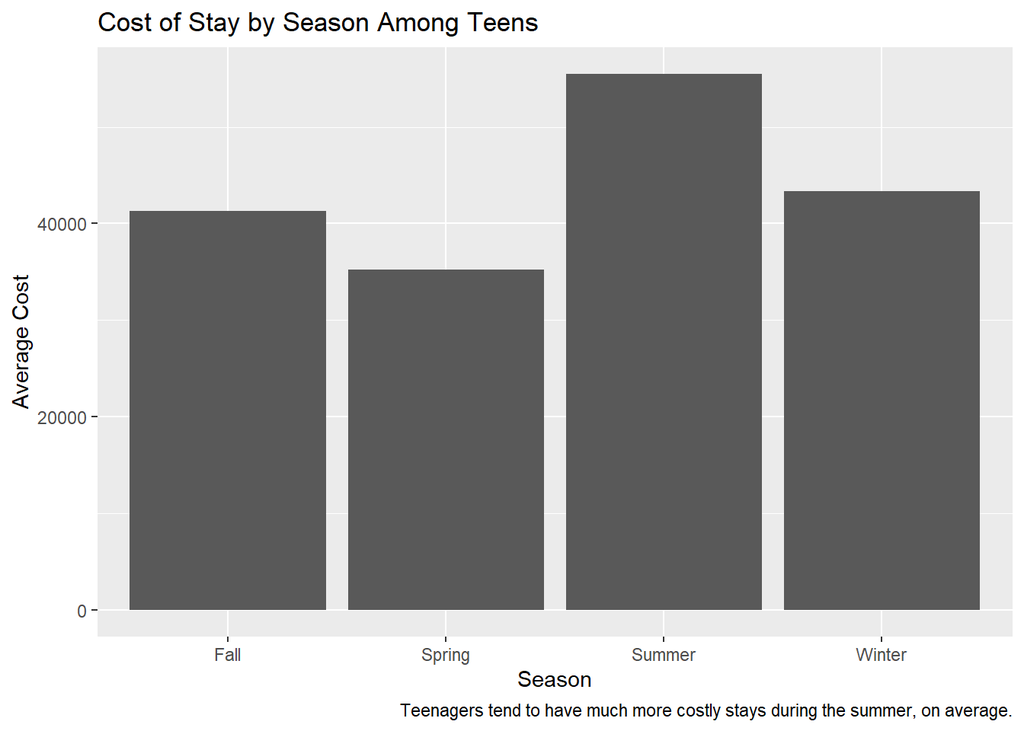

```r
df %>%
  filter(sex <=2, age >=13, age <=18) %>%
  group_by(season) %>%
  summarise(avg_tot= mean(tot)) %>%
  ggplot()+
  geom_col(mapping=aes(x=season, y=avg_tot))+labs(x='Season',
       y='Average Cost',
       title = 'Cost of Stay by Season Among Teens',
       caption = 'Teenagers tend to have much more costly stays during the summer, on average.')
```

```r
gg6 <- df %>%
  filter(sex <=2, age >=13, age <=18) %>%
  group_by(season) %>%
  summarise(avg_tot= mean(tot)) %>%
  ggplot()+
  geom_col(mapping=aes(x=season, y=avg_tot))+labs(x='Season',
       y='Average Cost',
       title = 'Cost of Stay by Season Among Teens',
       caption = 'Teenagers tend to have much more costly stays during the summer, on average.')

ggsave(filename = 'midtermplot6.png', plot = gg6)
```

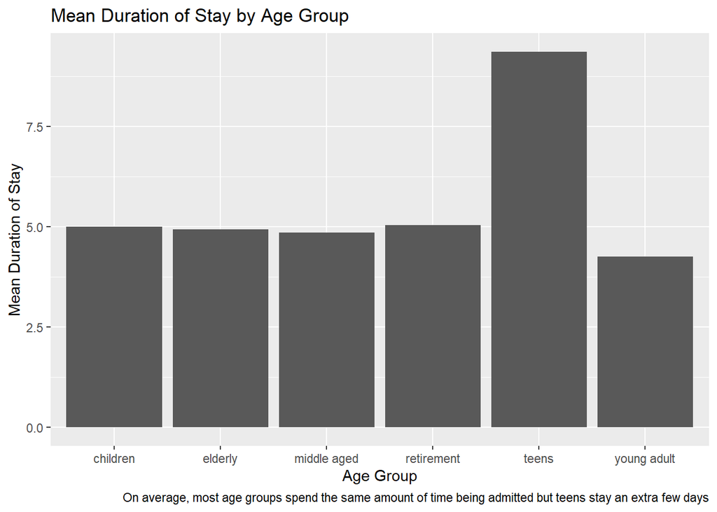

```r
df$agegroup <- case_when(df$age <=13 ~ 'children', df$age <=18 ~ 'teens', df$age <=35 ~ 'young adult', df$age <=60 ~ 'middle aged',df$age <=75 ~ 'retirement', TRUE ~ 'elderly')

 df %>%
  group_by(agegroup) %>%
  summarise(avg_los = mean(los)) %>%
  ggplot()+
  geom_col(aes(x=agegroup, y=avg_los, position = 'fill')) +labs(x='Age Group',
       y='Mean Duration of Stay',
       title = 'Mean Duration of Stay by Age Group',
       caption = 'On average, most age groups spend the same amount of time being admitted but teens stay an extra few days')
```

```r
 gg7 <- df %>%
  group_by(agegroup) %>%
  summarise(avg_los = mean(los)) %>%
  ggplot()+
  geom_col(aes(x=agegroup, y=avg_los, position = 'fill')) +labs(x='Age Group',
       y='Mean Duration of Stay',
       title = 'Mean Duration of Stay by Age Group',
       caption = 'On average, most age groups spend the same amount of time being admitted but teens stay an extra few days')

 ggsave(filename = 'midtermplot7.png', plot = gg7)
```

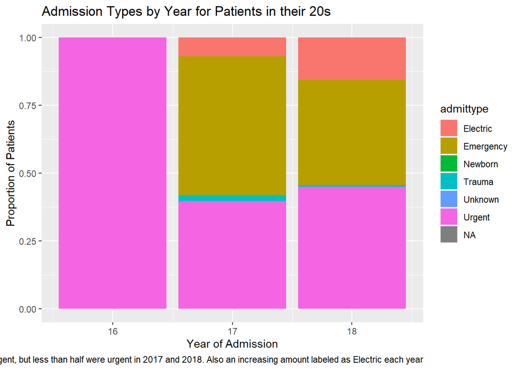

```r
df$admittype <- case_when(df$admtype %in% c(1) ~ 'Emergency',
  df$admtype %in% c(2)~ 'Urgent', df$admtype %in% c(3) ~ 'Electric',
  df$admtype %in% c(4)~ 'Newborn', df$admtype %in% c(5) ~ 'Trauma',
  df$admtype %in% c(9)~ 'Unknown')


df %>% filter(age >=20, age <=29) %>%
  ggplot()+
  geom_bar(mapping=aes(x=yoa, fill=admittype),
           position = 'fill') +labs(x='Year of Admission',
       y='Proportion of Patients',
       title = 'Admission Types by Year for Patients in their 20s',
       caption = 'In 2016, people in their 20s were all admitted as urgent, but less than half were urgent in 2017 and 2018. Also an increasing amount labeled as Electric each year')
```

```r
gg8 <- df %>% filter(age >=20, age <=29) %>%
  ggplot()+
  geom_bar(mapping=aes(x=yoa, fill=admittype),
           position = 'fill') +labs(x='Year of Admission',
       y='Proportion of Patients',
       title = 'Admission Types by Year for Patients in their 20s',
       caption = 'In 2016, people in their 20s were all admitted as urgent, but less than half were urgent in 2017 and 2018. Also an increasing amount labeled as Electric each year')

ggsave(filename = 'midtermplot8.png', plot = gg8)
```

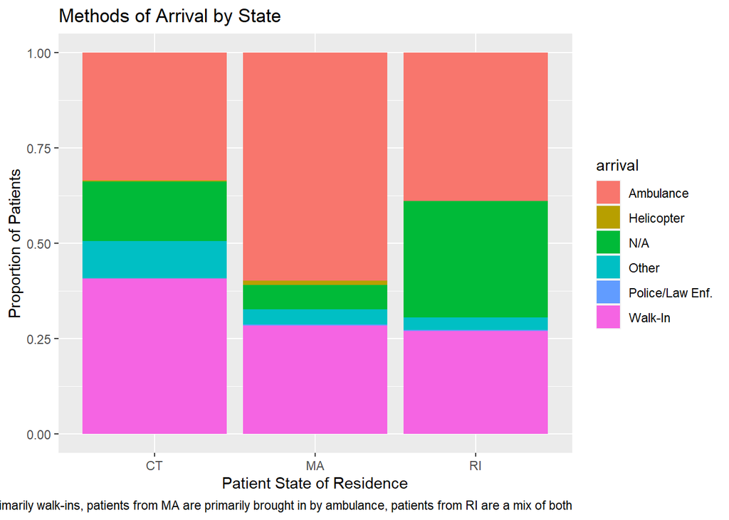

```r
df$arrival <- case_when(df$er_mode %in% c(0) ~ 'N/A',
  df$er_mode %in% c(1)~ 'Ambulance', df$er_mode %in% c(2) ~ 'Helicopter',
  df$er_mode %in% c(3)~ 'Police/Law Enf.', df$er_mode %in% c(4) ~ 'Walk-In',
  df$er_mode %in% c(5)~ 'Other', df$er_mode %in% c(6)~ 'Unknown')

df %>%
  filter(pt_state == "CT" | pt_state == "MA" | pt_state == "RI", er_mode < 6) %>%
  ggplot()+
  geom_bar(mapping=aes(x=pt_state, fill=arrival), position = 'fill') + labs(x='Patient State of Residence',
       y='Proportion of Patients',
       title = 'Methods of Arrival by State',
       caption = 'Patients from CT are primarily walk-ins, patients from MA are primarily brought in by ambulance, patients from RI are a mix of both')
```

```r
gg9 <- df %>%
  filter(pt_state == "CT" | pt_state == "MA" | pt_state == "RI", er_mode < 6) %>%
  ggplot()+
  geom_bar(mapping=aes(x=pt_state, fill=arrival), position = 'fill') + labs(x='Patient State of Residence',
       y='Proportion of Patients',
       title = 'Methods of Arrival by State',
       caption = 'Patients from CT are primarily walk-ins, patients from MA are primarily brought in by ambulance, patients from RI are a mix of both')

ggsave(filename = 'midtermplot9.png', plot = gg9)
```

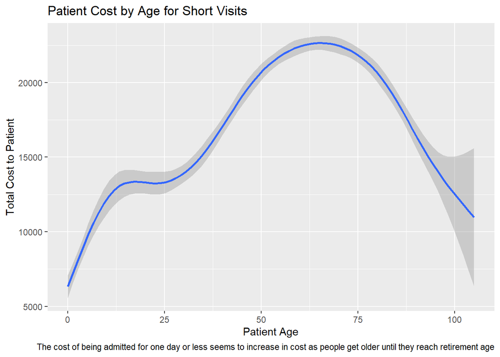

```r
df %>%
  filter(los<=1) %>%
  ggplot()+geom_smooth(aes(x=age, y=tot)) + labs(x='Patient Age',
       y='Total Cost to Patient',
       title = 'Patient Cost by Age for Short Visits',
       caption = 'The cost of being admitted for one day or less seems to increase in cost as people get older until they reach retirement age')
```

```r
gg10 <- df %>%
  filter(los<=1) %>%
  ggplot()+geom_smooth(aes(x=age, y=tot)) + labs(x='Patient Age',
       y='Total Cost to Patient',
       title = 'Patient Cost by Age for Short Visits',
       caption = 'The cost of being admitted for one day or less seems to increase in cost as people get older until they reach retirement age')

ggsave(filename = 'midtermplot10.png', plot = gg10)
```

2. Make an animation plot.

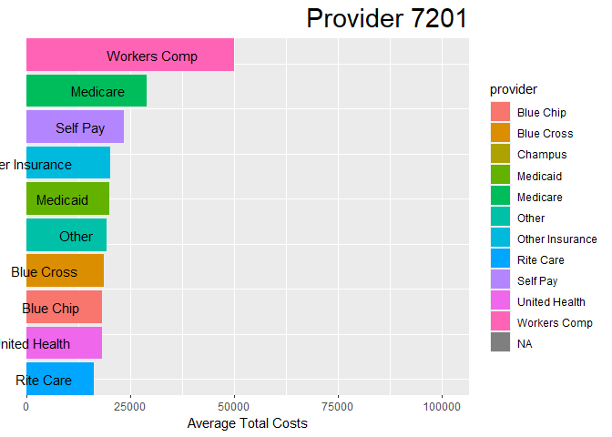

```r
library(gganimate)
library(ggplot2)
library(tidyverse)
library(knitr)

d1 <- df %>% group_by(provider, paytype) %>% summarise(avg_tot = mean(tot))
d2 <- d1 %>% group_by(provider) %>% mutate(rank=rank(-avg_tot))
d3 <- d2 %>% filter(rank <= 10)
a1 <- d3 %>% ggplot(aes(x=rank, y=avg_tot, group=paytype, fill=paytype, label=paytype)) + geom_col()+
    geom_text(aes(y = avg_tot, label = paytype), hjust = 1.4)+
    coord_flip(clip = "off", expand = FALSE) +scale_x_reverse()+
    labs(title = 'Provider {closest_state}', x='', y='Average Total Costs', fill='provider')+
    theme(plot.title = element_text(hjust = 1, size = 22),
          axis.ticks.y = element_blank(),
          axis.text.y  = element_blank()) +
    transition_states(provider)+
    ease_aes("cubic-in-out")
animate(a1, nframes = 400)

gg11 <- d3 %>% ggplot(aes(x=rank, y=avg_tot, group=paytype, fill=paytype, label=paytype)) + geom_col()+
    geom_text(aes(y = avg_tot, label = paytype), hjust = 1.4)+
    coord_flip(clip = "off", expand = FALSE) +scale_x_reverse()+
    labs(title = 'Provider {closest_state}', x='', y='Average Total Costs', fill='provider')+
    theme(plot.title = element_text(hjust = 1, size = 22),
          axis.ticks.y = element_blank(),
          axis.text.y  = element_blank()) +
    transition_states(provider)+
    ease_aes("cubic-in-out")
animate(a1, nframes = 400)
```

```r
anim_save(filename = 'midtermplot11.gif', plot = gg11)
```

[output not shown]

[output not shown]

## III. Predictive Models

Continue with the data from part I. Make sure you do not have any missing values in the data. Use the follows as the target and input variables:

*Target Variable*: Create the target variable taking value of

- `low` if the total charge of a patient (`tot`) is smaller than the median of the total charge, and
- `high` otherwise.

*Input Variables*:

- “age”,“sex”,“raceethn”,“provider”,“moa”,“mod”,“admtype”,“campus”, ‘los’

```r
df <- read_csv('midterm.jakecardines.csv')

df <- df %>%  select(-yod, -payfix, -pay_ub92, -yoa, - asource, -preopday, -service, -icu, -ccu, -dispub92, -payer, -drg, -trandb, -randbg, -randbs, -orr, -anes, -seq, -lab, -dtest, -ther, -blood, -phar, -other, -patcon, -bwght, -total, -ecodub92, -b_wt, -pt_state, -diag_adm, -ancilar, -er_fee, -er_chrg, -er_mode, -obs_chrg, -obs_hour, -psycchrg, -nicu_day)

median(df$tot)
```

```
## [1] 21854
```

```r
df$target <- case_when(df$tot < 21854 ~ 'low', TRUE ~ 'high')

write_csv(df, 'midtermpt3.jakecardines.csv')
```

```r
df <- df %>% select(-tot)
```

1. Use `filter` function to filter out rows where `raceethn==''` or `admtype==''`. Make sure all the categorical variables are factor, numeric variables are numeric. Set Training : Testing Split = 10 : 90

```r
df <- df %>%
  filter(!is.na(raceethn)) %>%
  filter(!is.na(admtype)) %>%
  filter(sex <=2) %>%
  filter(!is.na(admtype)) %>%
  filter(admtype <9)


 df$sex <- case_when(df$sex %in% c(1) ~ 'Male',
  df$sex %in% c(2)~ 'Female',df$sex %in% c(9)~ 'Unknown')

df$raceethn <- case_when(df$raceethn %in% c(1) ~ 'White',
  df$raceethn %in% c(2)~ 'Black', df$raceethn %in% c(3) ~ 'Asian', df$raceethn %in% c(4) ~ 'American Indian',
  df$raceethn %in% c(5)~ 'Native Hawaiian', df$raceethn %in% c(6) ~ 'Other', df$raceethn %in% c(7) ~ 'Hispanic',
  df$raceethn %in% c(9)~ 'Unknown')

df$provider <- case_when(df$provider %in% c(7201) ~ 'Newport',
  df$provider %in% c(7202)~ 'St. Joseph Health Services of RI', df$provider %in% c(7203) ~ 'Memorial', df$provider %in% c(7204) ~ 'Miriam',
  df$provider %in% c(7205)~ 'Rhode Island Hospital', df$provider %in% c(7206) ~ 'Roger Williams', df$provider %in% c(7209) ~ 'South County',
  df$provider %in% c(7210)~ 'Kent County', df$provider %in% c(7211)~ 'Westerly', df$provider %in% c(7212) ~ 'Rehab of RI', df$provider %in% c(7213) ~ 'Landmark Medical Center',
  df$provider %in% c(7214)~ 'Women and Infants', df$provider %in% c(7215)~ 'Bradley', df$provider %in% c(7216)~ 'Butler')


df$admtype <- case_when(df$admtype %in% c(1) ~ 'Emergency',
  df$admtype %in% c(2)~ 'Urgent', df$admtype %in% c(3) ~ 'Electric', df$admtype %in% c(4) ~ 'Newborn',
  df$admtype %in% c(5)~ 'Trauma',
  df$admtype %in% c(9)~ 'Not Available')


df$campus <- case_when(df$campus %in% c(0) ~ 'Hospital Has Only One Premise',
  df$campus %in% c(1)~ 'St. Joseph Health Services of Rhode
       Island – Our Lady of Fatima
       Hospital', df$campus %in% c(2) ~ 'St. Joseph Health Services of Rhode
      Island – St. Joseph Hospital for
     Specialty Care', df$campus %in% c(3) ~ 'Rhode Island Hospital - Adult')


 df %>%  mutate(target = as.factor(target),
         age = as.numeric(age),
         sex = as.factor(sex),
         raceethn = as.factor(raceethn),
         provider = as.factor(provider),
         moa = as.numeric(moa),
         mod = as.numeric(mod),
         admtype = as.factor(admtype),
         campus = as.factor(campus),
         los = as.numeric(los))
```

```
## # A tibble: 127,489 × 10
##      age sex    raceethn provider          moa   mod admtype   los campus target
##    <dbl> <fct>  <fct>    <fct>           <dbl> <dbl> <fct>   <dbl> <fct>  <fct>
##  1     0 Male   White    Women and Infa…     1     1 Newborn     2 Hospi… low
##  2    76 Female White    Women and Infa…     1     1 Electr…     1 Hospi… high
##  3    50 Female White    Women and Infa…    12     1 Urgent      3 Hospi… high
##  4     0 Male   Hispanic Women and Infa…     1     1 Newborn     4 Hospi… low
##  5     0 Male   White    Women and Infa…    12     1 Newborn    35 Hospi… high
##  6     0 Female Unknown  Women and Infa…    12     1 Newborn    17 Hospi… high
##  7     0 Female White    Women and Infa…     1     1 Newborn     2 Hospi… low
##  8     0 Female White    Women and Infa…     1     1 Newborn     3 Hospi… low
##  9    70 Female White    Women and Infa…     1     1 Urgent      2 Hospi… high
## 10    25 Female White    Women and Infa…    12     1 Urgent     12 Hospi… high
## # … with 127,479 more rows
```

```r
df$campus <- NULL
library(caret)

splitIndex <- createDataPartition(df$target, p = .10,
                                  list = FALSE)
df_train <- df[ splitIndex,]
df_test <- df[-splitIndex,]
```

2. Train a decision tree using `rpart`. Plot the decision tree. Plot the variable importance ranked by the tree.

[figure not shown]

```r
library(rpart)
tree_model <- rpart(target ~ ., data = df_train,
                 control = rpart.control(maxdepth = 3))

library(rattle)
fancyRpartPlot(tree_model)
```

```r
tree_model$variable.importance
```

```
##        los    admtype   provider        age   raceethn
## 1748.12162  463.72263  419.25066  215.39527   23.07265
```

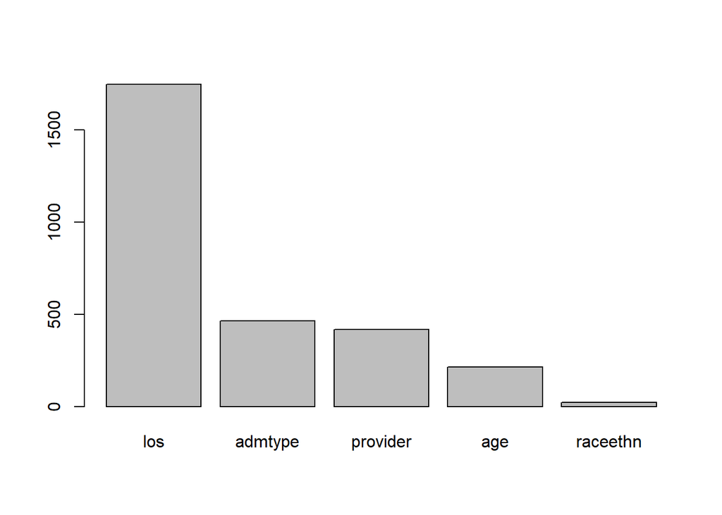

```r
barplot(tree_model$variable.importance)
```

3. Using caret for this question. Set `Training Control` to be: Use Cross-Validation of 5 folds across all models. Train & tune at least 2 different models (i.e. two different values for `method=` in the train function of caret). Plot the hyper-parameter tuning plots for each model.

```r
library(caret)
library(mlbench)

trControl = trainControl(method = "cv",
                         number = 5)
forest_ranger <- train(target~., data=df_train,
                    method = "ranger", trControl = trControl, na.action = na.omit)
pred <- predict(forest_ranger, df_test)
cm <- confusionMatrix(data = pred, reference = as.factor(df_test$target))
cm$overall
```

```
##       Accuracy          Kappa  AccuracyLower  AccuracyUpper   AccuracyNull
##   0.8256492941   0.6512825898   0.8234413819   0.8278407342   0.5063883563
## AccuracyPValue  McnemarPValue
##   0.0000000000   0.0002000789
```

```r
print(forest_ranger)
```

```
## Random Forest
##
## 12749 samples
##     8 predictor
##     2 classes: 'high', 'low'
##
## No pre-processing
## Resampling: Cross-Validated (5 fold)
## Summary of sample sizes: 10200, 10200, 10199, 10198, 10199
## Resampling results across tuning parameters:
##
##   mtry  splitrule   Accuracy   Kappa
##    2    gini        0.7912756  0.5821771
##    2    extratrees  0.6761301  0.3503063
##   14    gini        0.8236707  0.6473749
##   14    extratrees  0.8291607  0.6582856
##   26    gini        0.8164549  0.6329072
##   26    extratrees  0.8187291  0.6374004
##
## Tuning parameter 'min.node.size' was held constant at a value of 1
## Accuracy was used to select the optimal model using the largest value.
## The final values used for the model were mtry = 14, splitrule = extratrees
##  and min.node.size = 1.
```

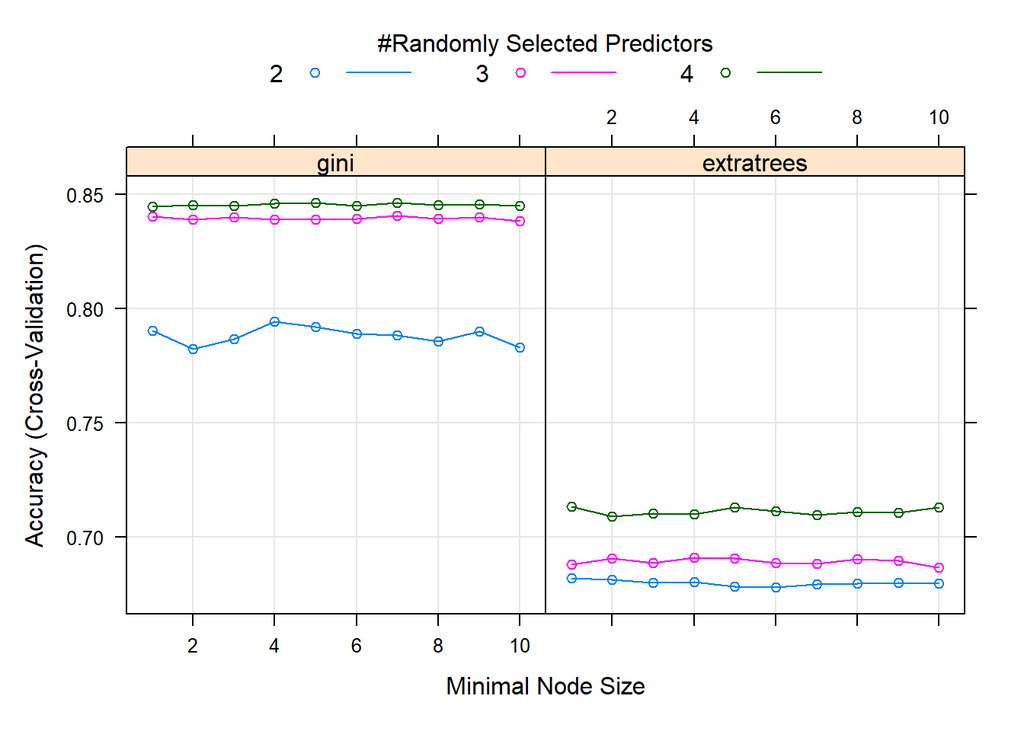

```r
trControl = trainControl(method = "cv",
                         number = 5)
tuneGrid = expand.grid(mtry = 2:4,
                       splitrule = c('gini', 'extratrees'),
                       min.node.size = c(1:10))
forest_ranger <- train(target~., data=df_train,
                    method = "ranger",
                    trControl = trControl,
                    tuneGrid = tuneGrid)
plot(forest_ranger)
```

```r
trControl = trainControl(method = "cv",
                         number = 5)
GLM <- train(target~., data=df_train,
                    method = "glmnet", trControl = trControl)
pred <- predict(GLM, df_test)
cm <- confusionMatrix(data = pred, reference = as.factor(df_test$target))
cm$overall
```

```
##       Accuracy          Kappa  AccuracyLower  AccuracyUpper   AccuracyNull
##   8.089158e-01   6.179126e-01   8.066288e-01   8.111872e-01   5.063884e-01
## AccuracyPValue  McnemarPValue
##   0.000000e+00   5.704149e-30
```

```r
print(GLM)
```

```
## glmnet
##
## 12749 samples
##     8 predictor
##     2 classes: 'high', 'low'
##
## No pre-processing
## Resampling: Cross-Validated (5 fold)
## Summary of sample sizes: 10199, 10200, 10198, 10200, 10199
## Resampling results across tuning parameters:
##
##   alpha  lambda        Accuracy   Kappa
##   0.10   0.0002810952  0.8184162  0.6368879
##   0.10   0.0028109521  0.8116705  0.6233821
##   0.10   0.0281095206  0.7835125  0.5667497
##   0.55   0.0002810952  0.8190437  0.6381443
##   0.55   0.0028109521  0.8145727  0.6292024
##   0.55   0.0281095206  0.7861795  0.5722809
##   1.00   0.0002810952  0.8188868  0.6378316
##   1.00   0.0028109521  0.8158278  0.6317285
##   1.00   0.0281095206  0.7671976  0.5348091
##
## Accuracy was used to select the optimal model using the largest value.
## The final values used for the model were alpha = 0.55 and lambda = 0.0002810952.
```

```r
getModelInfo('glmnet')$glmnet$parameters
```

```
##   parameter   class                    label
## 1     alpha numeric        Mixing Percentage
## 2    lambda numeric Regularization Parameter
```

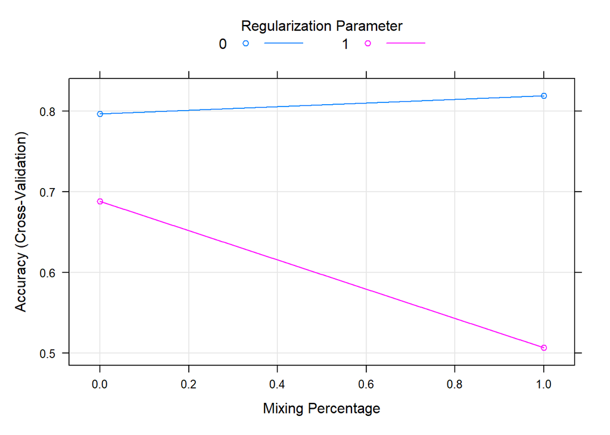

```r
trControl = trainControl(method = "cv",
                         number = 5)
tuneGrid = expand.grid(alpha = c(0:1),
                       lambda = c(0:1))
GLM <- train(target~., data=df_train,
                    method = "glmnet",
                    trControl = trControl,
                    tuneGrid = tuneGrid)
plot(GLM)
```

```r
trControl = trainControl(method = "cv",
                         number = 5)
FDA <- train(target~., data=df_train,
                    method = "fda", trControl = trControl)
pred <- predict(FDA, df_test)
cm <- confusionMatrix(data = pred, reference = as.factor(df_test$target))
cm$overall
```

```
##       Accuracy          Kappa  AccuracyLower  AccuracyUpper   AccuracyNull
##      0.8138836      0.6281764      0.8116193      0.8161319      0.5063884
## AccuracyPValue  McnemarPValue
##      0.0000000      0.0000000
```

```r
print(FDA)
```

```
## Flexible Discriminant Analysis
##
## 12749 samples
##     8 predictor
##     2 classes: 'high', 'low'
##
## No pre-processing
## Resampling: Cross-Validated (5 fold)
## Summary of sample sizes: 10199, 10199, 10200, 10199, 10199
## Resampling results across tuning parameters:
##
##   nprune  Accuracy   Kappa
##    2      0.7480582  0.4970073
##    8      0.7970823  0.5944831
##   14      0.8223388  0.6450653
##
## Tuning parameter 'degree' was held constant at a value of 1
## Accuracy was used to select the optimal model using the largest value.
## The final values used for the model were degree = 1 and nprune = 14.
```

```r
getModelInfo('fda')$fda$parameters
```

```
##   parameter   class          label
## 1    degree numeric Product Degree
## 2    nprune numeric         #Terms
```

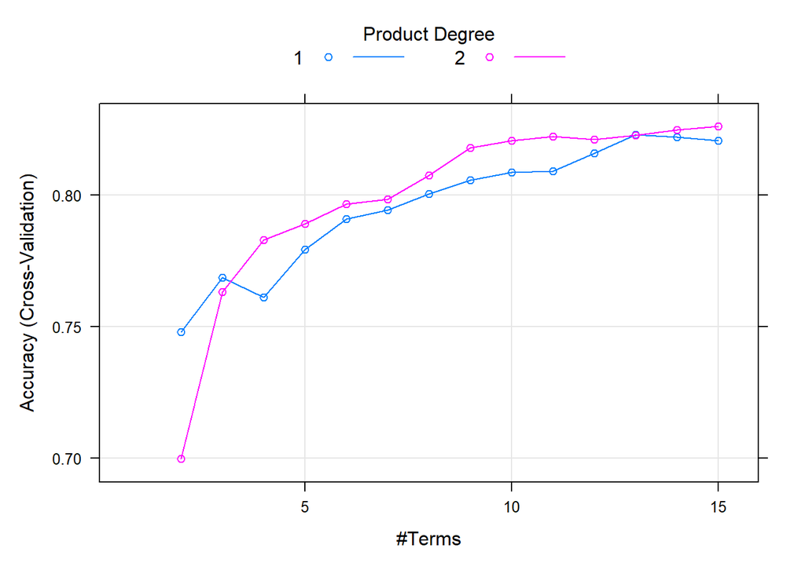

```r
trControl = trainControl(method = "cv",
                         number = 5)
tuneGrid = expand.grid(degree = c(1:2),
                       nprune = c(1:15))
FDA <- train(target~., data=df_train,
                    method = "fda",
                    trControl = trControl,
                    tuneGrid = tuneGrid)
plot(FDA)
```

4. Plot the comparison of the models in 3.

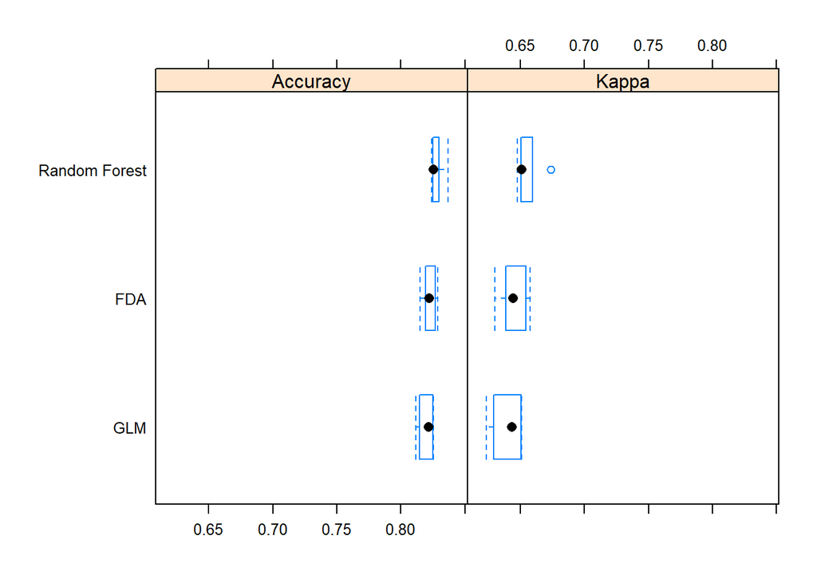

```r
trControl = trainControl(method = "cv",
                         number = 5)
GLM <- train(target~., data=df_train,
                                method = "glmnet",
                                trControl = trControl)
forest_ranger <- train(target~., data=df_train,
                    method = "ranger",
                                trControl = trControl)
FDA <- train(target~., data=df_train,
                                method = "fda",
                                trControl = trControl)
results <- resamples(list('GLM' = GLM,
                          'Random Forest' = forest_ranger,
                          'FDA'= FDA))
bwplot(results)
```

5. What is your final selection for the model? Test the accuracy of your final model on the test data.

```r
'The ranger method is the best of the three, so we choose that one'
```

```
## [1] "The ranger method is the best of the three, so we choose that one"
```

```r
pred <- predict(forest_ranger, df_test)
cm <- confusionMatrix(data = pred, reference = as.factor(df_test$target))


cm$overall[1]
```

```
##  Accuracy
## 0.8260066
```

6. Create another `target` variable (binary), decide the input variables and redo 1 to 5.

```r
df <- read_csv('midterm.jakecardines.csv')

df <- df %>%  select(-yod, -payfix, -pay_ub92, -yoa, - asource, -preopday, -service, -icu, -ccu, -dispub92, -payer, -drg, -trandb, -randbg, -randbs, -orr, -anes, -seq, -lab, -dtest, -ther, -blood, -phar, -other, -patcon, -bwght, -total, -ecodub92, -b_wt, -pt_state, -diag_adm, -ancilar, -er_fee, -er_chrg, -er_mode, -obs_chrg, -obs_hour, -psycchrg, -nicu_day)


df$target <- case_when(df$los < 5 ~ 'short', TRUE ~ 'long')

write_csv(df, 'midtermpt3q6.jakecardines.csv')
```

```r
df <- df %>% select(-los)
```

```r
df <- df %>%
  filter(!is.na(raceethn)) %>%
  filter(!is.na(admtype)) %>%
  filter(sex <=2) %>%
  filter(!is.na(admtype)) %>%
  filter(admtype <9)


 df$sex <- case_when(df$sex %in% c(1) ~ 'Male',
  df$sex %in% c(2)~ 'Female',df$sex %in% c(9)~ 'Unknown')

df$raceethn <- case_when(df$raceethn %in% c(1) ~ 'White',
  df$raceethn %in% c(2)~ 'Black', df$raceethn %in% c(3) ~ 'Asian', df$raceethn %in% c(4) ~ 'American Indian',
  df$raceethn %in% c(5)~ 'Native Hawaiian', df$raceethn %in% c(6) ~ 'Other', df$raceethn %in% c(7) ~ 'Hispanic',
  df$raceethn %in% c(9)~ 'Unknown')

df$provider <- case_when(df$provider %in% c(7201) ~ 'Newport',
  df$provider %in% c(7202)~ 'St. Joseph Health Services of RI', df$provider %in% c(7203) ~ 'Memorial', df$provider %in% c(7204) ~ 'Miriam',
  df$provider %in% c(7205)~ 'Rhode Island Hospital', df$provider %in% c(7206) ~ 'Roger Williams', df$provider %in% c(7209) ~ 'South County',
  df$provider %in% c(7210)~ 'Kent County', df$provider %in% c(7211)~ 'Westerly', df$provider %in% c(7212) ~ 'Rehab of RI', df$provider %in% c(7213) ~ 'Landmark Medical Center',
  df$provider %in% c(7214)~ 'Women and Infants', df$provider %in% c(7215)~ 'Bradley', df$provider %in% c(7216)~ 'Butler')


df$admtype <- case_when(df$admtype %in% c(1) ~ 'Emergency',
  df$admtype %in% c(2)~ 'Urgent', df$admtype %in% c(3) ~ 'Electric', df$admtype %in% c(4) ~ 'Newborn',
  df$admtype %in% c(5)~ 'Trauma',
  df$admtype %in% c(9)~ 'Not Available')


df$campus <- case_when(df$campus %in% c(0) ~ 'Hospital Has Only One Premise',
  df$campus %in% c(1)~ 'St. Joseph Health Services of Rhode
       Island – Our Lady of Fatima
       Hospital', df$campus %in% c(2) ~ 'St. Joseph Health Services of Rhode
      Island – St. Joseph Hospital for
     Specialty Care', df$campus %in% c(3) ~ 'Rhode Island Hospital - Adult')


 df %>%  mutate(target = as.factor(target),
         age = as.numeric(age),
         sex = as.factor(sex),
         raceethn = as.factor(raceethn),
         provider = as.factor(provider),
         moa = as.numeric(moa),
         mod = as.numeric(mod),
         admtype = as.factor(admtype),
         campus = as.factor(campus),
         tot = as.numeric(tot))
```

```
## # A tibble: 127,489 × 10
##      age sex    raceethn provider         moa   mod admtype    tot campus target
##    <dbl> <fct>  <fct>    <fct>          <dbl> <dbl> <fct>    <dbl> <fct>  <fct>
##  1     0 Male   White    Women and Inf…     1     1 Newborn   3653 Hospi… short
##  2    76 Female White    Women and Inf…     1     1 Electr…  44075 Hospi… short
##  3    50 Female White    Women and Inf…    12     1 Urgent   99235 Hospi… short
##  4     0 Male   Hispanic Women and Inf…     1     1 Newborn   5412 Hospi… short
##  5     0 Male   White    Women and Inf…    12     1 Newborn  93547 Hospi… long
##  6     0 Female Unknown  Women and Inf…    12     1 Newborn 207366 Hospi… long
##  7     0 Female White    Women and Inf…     1     1 Newborn   3242 Hospi… short
##  8     0 Female White    Women and Inf…     1     1 Newborn   4312 Hospi… short
##  9    70 Female White    Women and Inf…     1     1 Urgent   44173 Hospi… short
## 10    25 Female White    Women and Inf…    12     1 Urgent   60430 Hospi… long
## # … with 127,479 more rows
```

```r
df$campus <- NULL
library(caret)

splitIndex <- createDataPartition(df$target, p = .10,
                                  list = FALSE)
df_train <- df[ splitIndex,]
df_test <- df[-splitIndex,]
```

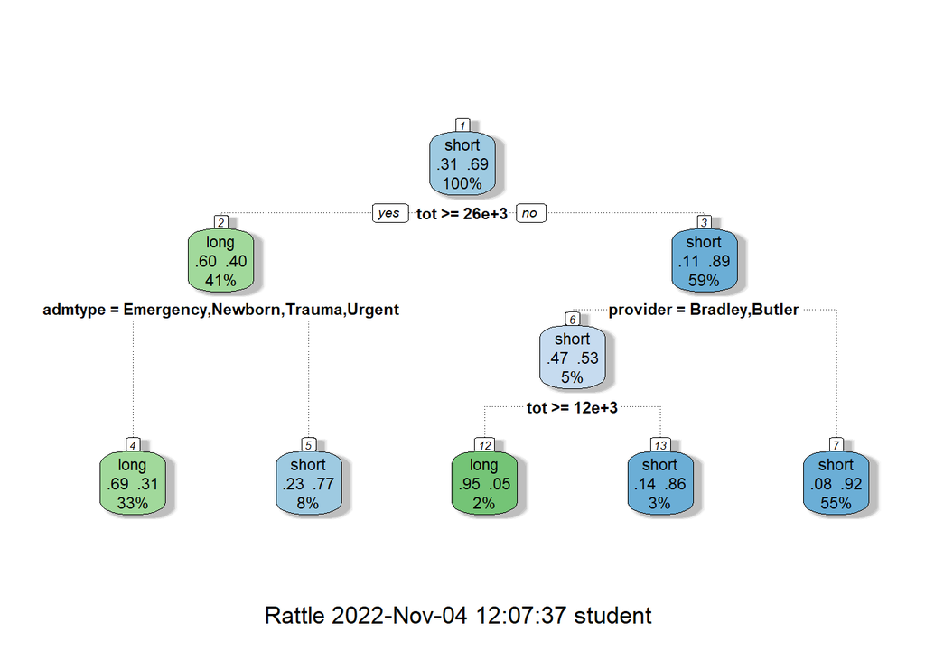

```r
library(rpart)
tree_model <- rpart(target ~ ., data = df_train,
                 control = rpart.control(maxdepth = 3))

library(rattle)
fancyRpartPlot(tree_model)
```

```r
tree_model$variable.importance
```

```
##         tot     admtype    provider         age         mod    raceethn
## 1659.632624  462.601975  327.309514  111.566203    2.329930    1.553287
```

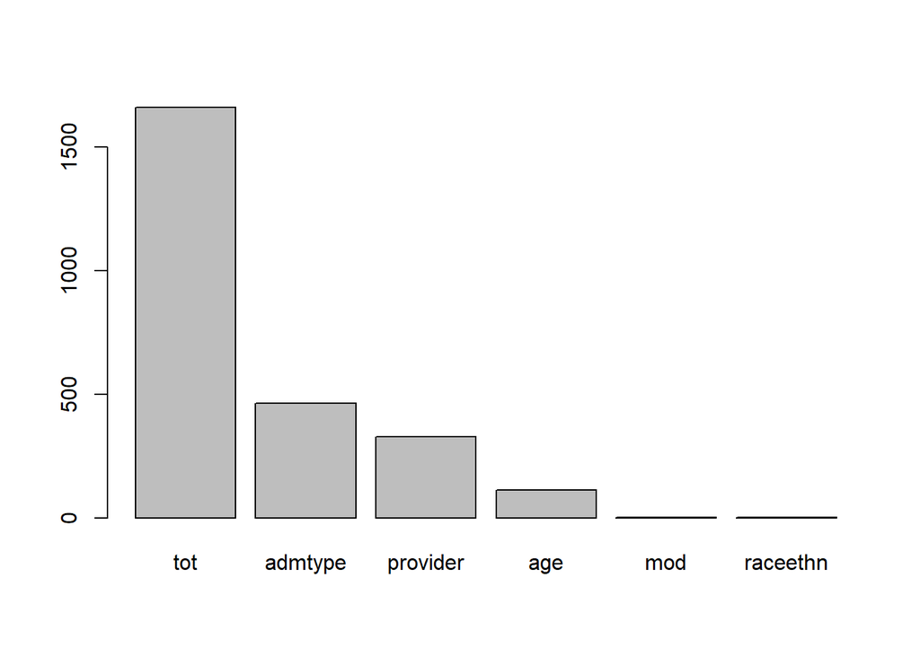

```r
barplot(tree_model$variable.importance)
```

```r
trControl = trainControl(method = "cv",
                         number = 5)
forest_ranger <- train(target~., data=df_train,
                    method = "ranger", trControl = trControl, na.action = na.omit)
pred <- predict(forest_ranger, df_test)
cm <- confusionMatrix(data = pred, reference = as.factor(df_test$target))
cm$overall
```

```
##       Accuracy          Kappa  AccuracyLower  AccuracyUpper   AccuracyNull
##   8.435928e-01   6.316741e-01   8.414780e-01   8.456903e-01   6.865408e-01
## AccuracyPValue  McnemarPValue
##   0.000000e+00   6.717487e-40
```

```r
print(forest_ranger)
```

```
## Random Forest
##
## 12750 samples
##     8 predictor
##     2 classes: 'long', 'short'
##
## No pre-processing
## Resampling: Cross-Validated (5 fold)
## Summary of sample sizes: 10200, 10201, 10199, 10201, 10199
## Resampling results across tuning parameters:
##
##   mtry  splitrule   Accuracy   Kappa
##    2    gini        0.7436119  0.24464050
##    2    extratrees  0.6939607  0.04360441
##   14    gini        0.8393723  0.62536554
##   14    extratrees  0.8440777  0.63106154
##   26    gini        0.8368633  0.61970605
##   26    extratrees  0.8405496  0.62683162
##
## Tuning parameter 'min.node.size' was held constant at a value of 1
## Accuracy was used to select the optimal model using the largest value.
## The final values used for the model were mtry = 14, splitrule = extratrees
##  and min.node.size = 1.
```

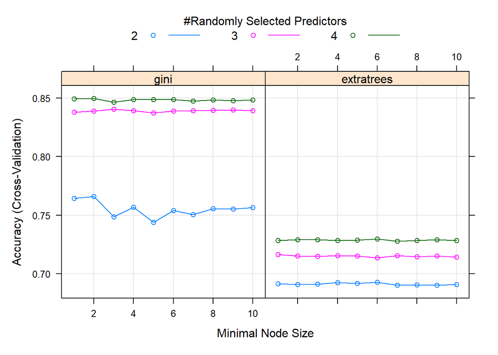

```r
trControl = trainControl(method = "cv",
                         number = 5)
tuneGrid = expand.grid(mtry = 2:4,
                       splitrule = c('gini', 'extratrees'),
                       min.node.size = c(1:10))
forest_ranger <- train(target~., data=df_train,
                    method = "ranger",
                    trControl = trControl,
                    tuneGrid = tuneGrid)
plot(forest_ranger)
```

```r
trControl = trainControl(method = "cv",
                         number = 5)
GLM <- train(target~., data=df_train,
                    method = "glmnet", trControl = trControl)
pred <- predict(GLM, df_test)
cm <- confusionMatrix(data = pred, reference = as.factor(df_test$target))
cm$overall
```

```
##       Accuracy          Kappa  AccuracyLower  AccuracyUpper   AccuracyNull
##      0.8270597      0.5644981      0.8248587      0.8292441      0.6865408
## AccuracyPValue  McnemarPValue
##      0.0000000      0.0000000
```

```r
print(GLM)
```

```
## glmnet
##
## 12750 samples
##     8 predictor
##     2 classes: 'long', 'short'
##
## No pre-processing
## Resampling: Cross-Validated (5 fold)
## Summary of sample sizes: 10200, 10200, 10200, 10201, 10199
## Resampling results across tuning parameters:
##
##   alpha  lambda        Accuracy   Kappa
##   0.10   0.0003316451  0.8282346  0.5669258
##   0.10   0.0033164506  0.8196856  0.5375441
##   0.10   0.0331645060  0.7807841  0.3927463
##   0.55   0.0003316451  0.8287053  0.5684290
##   0.55   0.0033164506  0.8205486  0.5407593
##   0.55   0.0331645060  0.7704307  0.3578782
##   1.00   0.0003316451  0.8290975  0.5697001
##   1.00   0.0033164506  0.8210191  0.5433124
##   1.00   0.0331645060  0.7690192  0.3584840
##
## Accuracy was used to select the optimal model using the largest value.
## The final values used for the model were alpha = 1 and lambda = 0.0003316451.
```

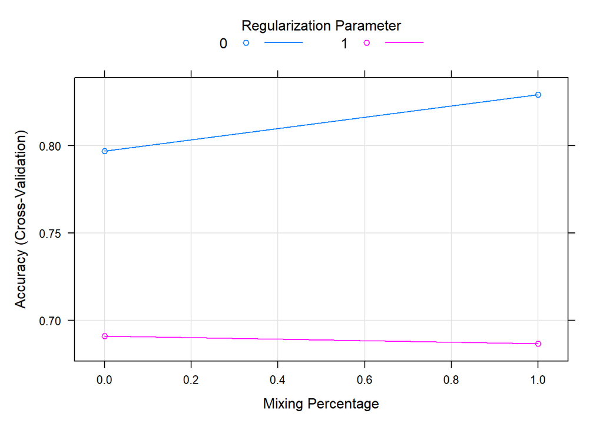

```r
trControl = trainControl(method = "cv",
                         number = 5)
tuneGrid = expand.grid(alpha = c(0:1),
                       lambda = c(0:1))
GLM <- train(target~., data=df_train,
                    method = "glmnet",
                    trControl = trControl,
                    tuneGrid = tuneGrid)
plot(GLM)
```

```r
trControl = trainControl(method = "cv",
                         number = 5)
FDA <- train(target~., data=df_train,
                    method = "fda", trControl = trControl)
pred <- predict(FDA, df_test)
cm <- confusionMatrix(data = pred, reference = as.factor(df_test$target))
cm$overall
```

```
##       Accuracy          Kappa  AccuracyLower  AccuracyUpper   AccuracyNull
##   8.382154e-01   6.156586e-01   8.360717e-01   8.403420e-01   6.865408e-01
## AccuracyPValue  McnemarPValue
##   0.000000e+00  3.257146e-101
```